# Taxi Project Descriptive Analysis

Brad Dixon rbdixon@gmail.com

May 7, 2015

# Data Sets

## Train

```r
print(glimpse(TRAIN_RAW))
```

```
## Observations: 1710670
## Variables:
## $ TRIP_ID      (chr) "1372956749620000904", "1372947499620000296", "13...
## $ CALL_TYPE    (chr) "C", "B", "C", "B", "B", "B", "A", "B", "B", "B",...
## $ ORIGIN_CALL  (chr) "", "", "", "", "", "", "37538", "", "", "", "", ...
## $ ORIGIN_STAND (chr) "", "11", "", "15", "27", "23", "", "50", "15", "...
## $ TAXI_ID      (int) 20000904, 20000296, 20000377, 20000140, 20000523,...
## $ TIMESTAMP    (int) 1372956749, 1372947499, 1372954427, 1372953743, 1...
## $ DAY_TYPE     (chr) "A", "A", "A", "A", "A", "A", "A", "A", "A", "A",...
## $ MISSING_DATA (lgl) FALSE, FALSE, FALSE, FALSE, FALSE, FALSE, FALSE, ...
## $ POLYLINE     (chr) "[[-8.60895,41.146911],[-8.608806,41.147064],[-8....
## $ id           (dbl) 17620, 17621, 17622, 17623, 17624, 17625, 17626, ...
## NULL
```

## Test

```r
print(glimpse(TEST_RAW))
```

```
## Observations: 320
## Variables:
## $ TRIP_ID      (chr) "T1", "T2", "T3", "T4", "T5", "T6", "T7", "T8", "...
## $ CALL_TYPE    (chr) "B", "B", "B", "B", "B", "A", "B", "A", "B", "B",...
## $ ORIGIN_CALL  (chr) NA, NA, NA, NA, NA, "42612", NA, "31780", NA, NA,...
## $ ORIGIN_STAND (chr) "15", "57", "15", "53", "18", NA, "15", NA, "9", ...
## $ TAXI_ID      (int) 20000542, 20000108, 20000370, 20000492, 20000621,...
## $ TIMESTAMP    (int) 1408039037, 1408038611, 1408038568, 1408039090, 1...
## $ DAY_TYPE     (chr) "A", "A", "A", "A", "A", "A", "A", "A", "A", "A",...
## $ MISSING_DATA (lgl) FALSE, FALSE, FALSE, FALSE, FALSE, FALSE, FALSE, ...
## $ POLYLINE     (chr) "[[-8.585676,41.148522],[-8.585712,41.148639],[-8...
## $ id           (dbl) 1, 2, 3, 4, 5, 6, 7, 8, 9, 10, 11, 12, 13, 14, 15...
## NULL
```

# Variables

## TRIP_ID

> TRIP_ID: (String) It contains an unique identifier for each trip;

Assumptions:

- Trip IDs are assigned to each row in train and test data sets.
- Trip IDs are unique across train and test data sets.

```r
DATA %>%
  group_by(dataset) %>%
  filter(is.na(TRIP_ID)) %>%
  summarize(n = n()) %>%
  filter(n > 1) %>%
  group_by(dataset) %>%
  summarize(num_trip_id_NA = n()) %>%
  collect
```

```
## Source: local data frame [0 x 0]
```

```r
DATA %>%
  group_by(dataset, TRIP_ID) %>%
  summarize(n = n()) %>%
  filter(n > 1) %>%
  group_by(dataset) %>%
  summarize(num_trip_id_duplicated = n()) %>%
  collect
```

```
## Source: local data frame [1 x 2]
##
##   dataset num_trip_id_duplicated
## 1   TRAIN                     78
```

Finding:

- TEST, TRAIN: No NA TRIP_ID’s.
- TRAIN: Trip IDs are duplicated.

## CALL_TYPE

> CALL_TYPE: (char) It identifies the way used to demand this service. It may contain one of three possible values: ‘A’ if this trip was dispatched from the central; ‘B’ if this trip was demanded directly to a taxi driver on a specific stand; ‘C’ otherwise (i.e. a trip demanded on a random street).

Assumptions:

- No missing values
- A, B, and C levels are found in both train and test
- No unexpected values

```r
DATA %>%
  group_by(dataset, CALL_TYPE) %>%
  summarize(n = n()) %>%
  arrange(dataset, CALL_TYPE) %>%
  collect %>%
  spread(CALL_TYPE, n)
```

```
## Source: local data frame [2 x 4]
##
##   dataset      A      B      C
## 1    TEST     72    123    125
## 2   TRAIN 364770 817881 528016
```

Finding:

- All assumptions confirmed.

## ORIGIN_CALL

> ORIGIN_CALL: (integer) It contains an unique identifier for each phone number which was used to demand, at least, one service. It identifies the trip’s customer if CALL_TYPE=’A’. Otherwise, it assumes a NULL value;

Assumptions:

- Most “A” type taxi calls have a ORIGIN_CALL identifier assigned.
- ORIGIN_CALL identifiers are persistent to the phone as indicated by some identifiers taking repeated cab rides.
- Some ORIGIN_CALL identifiers will be found in training and test sets.

```r
# How many records have ORIGIN_CALL assigned by CALL_TYPE?
DATA %>%
  mutate(
    origin_call_assigned = ORIGIN_CALL!="" & !is.na(ORIGIN_CALL)
  ) %>%
  group_by(dataset, CALL_TYPE, origin_call_assigned) %>%
  summarize(n = n()) %>%
  collect %>%
  spread(origin_call_assigned, n)
```

```
## Source: local data frame [6 x 4]
##
##   dataset CALL_TYPE  FALSE   TRUE
## 1    TEST         A     NA     72
## 2    TEST         B    123     NA
## 3    TEST         C    125     NA
## 4   TRAIN         A     NA 364770
## 5   TRAIN         B 817881     NA
## 6   TRAIN         C 528016     NA
```

```r
# How many distinct ORIGIN_CALL ID's have taken multiple trips?
DATA %>%
  group_by(dataset, ORIGIN_CALL) %>%
  summarize(multiple_trips = n()>1) %>%
  group_by(dataset, multiple_trips) %>%
  summarize(n = n()) %>%
  arrange(dataset, multiple_trips) %>%
  collect %>%
  spread(multiple_trips, n)
```

```
## Source: local data frame [2 x 3]
##
##   dataset FALSE  TRUE
## 1    TEST    58     3
## 2   TRAIN 28079 29027
```

```r
# How many ORIGIN_CALL ID's are found in both data sets?
DATA %>%
  filter(!is.na(ORIGIN_CALL), ORIGIN_CALL!="") %>%
  select(dataset, ORIGIN_CALL) %>%
  distinct %>%
  group_by(ORIGIN_CALL) %>%
  summarize(
    in_train_and_test = any(dataset=="TRAIN") & any(dataset=="TEST")
  ) %>%
  group_by(in_train_and_test) %>%
  summarize(n=n()) %>%
  collect
```

```
## Source: local data frame [2 x 2]
##
##   in_train_and_test     n
## 1             FALSE 57083
## 2              TRUE    41
```

```r
# Top ORIGIN_CALL ID's
DATA %>%
  filter(!is.na(ORIGIN_CALL), ORIGIN_CALL!="") %>%
  group_by(dataset, ORIGIN_CALL) %>%
  summarize(n=n()) %>%
  filter(n>1) %>%
  group_by(dataset) %>%
  top_n(10, n) %>%
  collect
```

```
## Source: local data frame [12 x 3]
## Groups: dataset
##
##    dataset ORIGIN_CALL     n
## 1     TEST        2002    12
## 2     TEST        4785     2
## 3    TRAIN        2002 57571
## 4    TRAIN       63882  6406
## 5    TRAIN        2001  2499
## 6    TRAIN       13168  1314
## 7    TRAIN        6728  1115
## 8    TRAIN        5591  1051
## 9    TRAIN       14123   990
## 10   TRAIN        6654   909
## 11   TRAIN        2024   800
## 12   TRAIN       14045   769
```

Findings:

- TEST, TRAIN: Empty string or NA indicates missing ORIGIN_CALL assignment.
- TEST, TRAIN: Only CALL_TYPE==“A” have ORIGIN_CALL assigned.
- The train data set has many repeat trips by identified phone numbers (ORIGIN_CALL).
- The test data set is mostly one-trip per phone number. This makes sense since test is multiple snapshots in time.
- Very few ORIGIN_CALL ID’s are found in both train and test.
- Some ORIGIN_CALL ID’s are very frequent callers?
- ORIGIN_CALL identifier 2002 is a very frequent taxi requester. Possibly a hotel or a veiled NA?

## ORIGIN_STAND

> ORIGIN_STAND: (integer): It contains an unique identifier for the taxi stand. It identifies the starting point of the trip if CALL_TYPE=’B’. Otherwise, it assumes a NULL value

Assumptions:

- Most ORIGIN_STAND == “B” calls will have a taxi stand identifier but not all will.
- Stands are frequent repeat callers of taxis.

```r
# How frequently is ORIGIN_STAND assigned by CALL_TYPE?
DATA %>%
  group_by(dataset, CALL_TYPE) %>%
  mutate(
    origin_stand_assigned = ORIGIN_STAND!="" & !is.na(ORIGIN_STAND)
  ) %>%
  group_by(dataset, CALL_TYPE, origin_stand_assigned) %>%
  summarize(n=n()) %>%
  collect %>%
  arrange(dataset, CALL_TYPE) %>%
  spread(origin_stand_assigned, n)
```

```
## Source: local data frame [6 x 4]
##
##   dataset CALL_TYPE  FALSE   TRUE
## 1    TEST         A     72     NA
## 2    TEST         B     NA    123
## 3    TEST         C    125     NA
## 4   TRAIN         A 364770     NA
## 5   TRAIN         B  11302 806579
## 6   TRAIN         C 528016     NA
```

```r
# Top ORIGIN_STANDs
DATA %>%
  group_by(dataset, ORIGIN_STAND) %>%
  summarize(n=n()) %>%
  filter(n>1) %>%
  top_n(10, n) %>%
  collect %>%
  print.data.frame()
```

```
##    dataset ORIGIN_STAND      n
## 1     TEST         <NA>    197
## 2     TEST           15     21
## 3     TEST           57     13
## 4     TEST            9      7
## 5     TEST           23      6
## 6     TEST           53      6
## 7     TEST           60      4
## 8     TEST           35      4
## 9     TEST           13      4
## 10    TEST           33      3
## 11    TEST           16      3
## 12    TEST           47      3
## 13    TEST           18      3
## 14    TEST           36      3
## 15    TEST           14      3
## 16    TEST           38      3
## 17    TEST           25      3
## 18    TEST           10      3
## 19    TEST           28      3
## 20   TRAIN              904088
## 21   TRAIN           15  80241
## 22   TRAIN           57  50882
## 23   TRAIN            9  34818
## 24   TRAIN           33  34128
## 25   TRAIN           23  33344
## 26   TRAIN           18  32937
## 27   TRAIN           53  31712
## 28   TRAIN           13  25685
## 29   TRAIN           12  25434
```

Findings:

- TRAIN, TEST: ORIGIN_STAND can be either NA or “”.
- TEST: There are examples of CALL_TYPE==“B” and ORIGIN_STAND in train but none are found in TEST.

## TAXI_ID

> TAXI_ID: (integer): It contains an unique identifier for the taxi driver that performed each trip;

Assumptions:

- TAXI_ID will not be missing

```r
# Are TAXI_ID's always assigned?
DATA %>%
  group_by(dataset) %>%
  mutate(
    taxi_id_assigned = !is.na(TAXI_ID)
  ) %>%
  group_by(dataset, taxi_id_assigned) %>%
  summarize(n=n()) %>%
  collect %>%
  spread(taxi_id_assigned, n)
```

```
## Source: local data frame [2 x 2]
##
##   dataset    TRUE
## 1    TEST     320
## 2   TRAIN 1710667
```

```r
# Top Taxi ID's
DATA %>%
  group_by(dataset, TAXI_ID) %>%
  summarize(n=n()) %>%
  filter(n>1) %>%
  top_n(10, n) %>%
  collect %>%
  print.data.frame()
```

```
##    dataset  TAXI_ID     n
## 1     TEST 20000434     4
## 2     TEST 20000081     3
## 3     TEST 20000129     3
## 4     TEST 20000250     3
## 5     TEST 20000436     3
## 6     TEST 20000503     3
## 7     TEST 20000612     3
## 8     TEST 20000334     3
## 9     TEST 20000686     2
## 10    TEST 20000565     2
## 11    TEST 20000010     2
## 12    TEST 20000159     2
## 13    TEST 20000391     2
## 14    TEST 20000596     2
```

[output cut: 63 more lines]

Findings:

- Assumptions confirmed.
- TEST: Most taxi drivers are observed once in the test data.

## TIMESTAMP

> TIMESTAMP: (integer) Julian Timestamp (in seconds). It identifies the trip’s start

Assumptions:

- Origin is 1970-01-01. This means it isn’t really a Julian timestamp.
- Timezone is UTC

Testing data set date range:

> Five test sets will be available to evaluate your predictive framework (in one single CSV file named “test.csv”). Each one of these datasets refer to trips that occurred between 01/07/2014 and 31/12/2014. Each one of these data sets will provide a snapshot of the current network status on a given timestamp. It will provide partial trajectories for each one of the on-going trips during that specific moment. The five snapshots included on the test set refer to the following timestamps:
> - 14/08/2014 18:00:00
> - 30/09/2014 08:30:00
> - 06/10/2014 17:45:00
> - 01/11/2014 04:00:00
> - 21/12/2014 14:30:00

```r
DATA %>%
  group_by(dataset) %>%
  summarize(
    mindt = to_timestamp(min(TIMESTAMP)),
    maxdt = to_timestamp(max(TIMESTAMP))
  ) %>%
  collect
```

```
## Source: local data frame [2 x 3]
##
##   dataset               mindt               maxdt
## 1    TEST 2014-08-14 12:02:23 2014-12-21 09:29:19
## 2   TRAIN 2013-06-30 20:00:53 2014-06-30 19:59:56
```

```
## stat_bin: binwidth defaulted to range/30. Use 'binwidth = x' to adjust this.
```

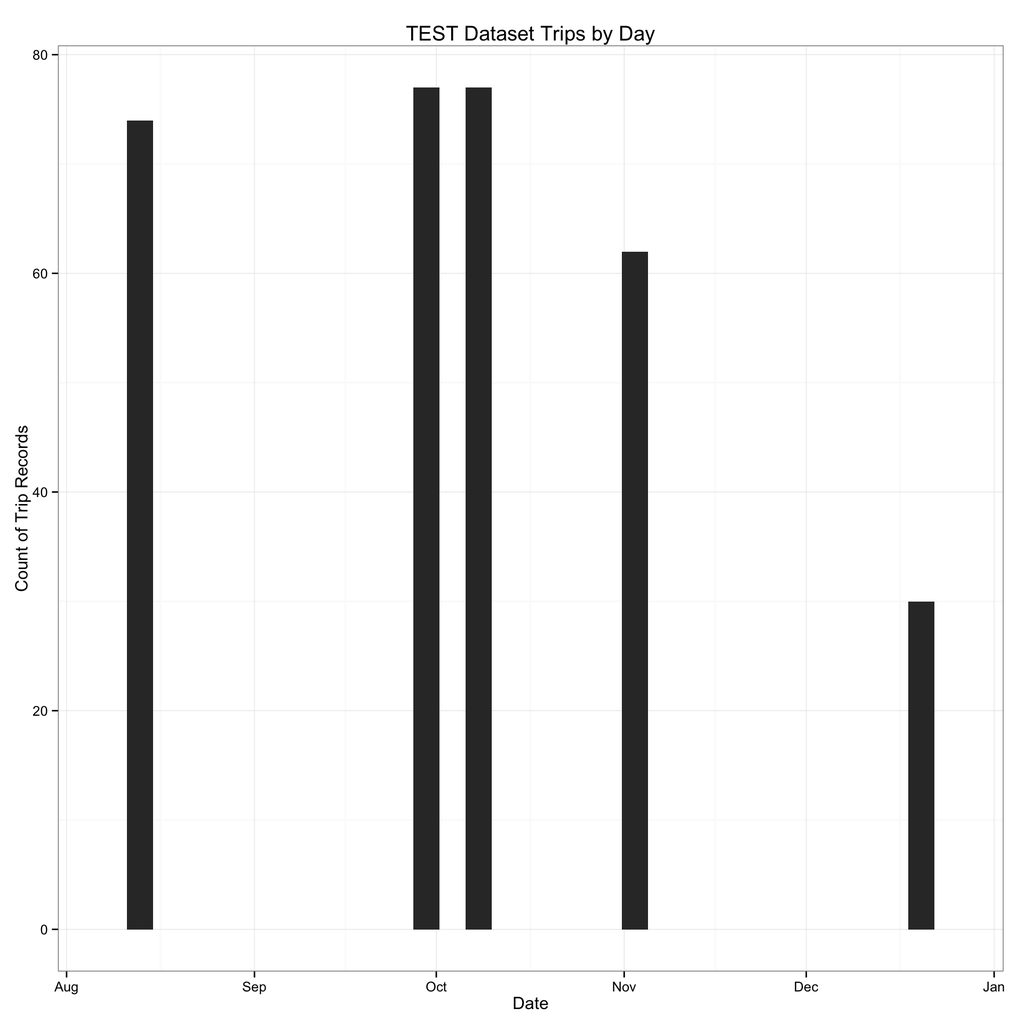

```r
TEST_RAW %>%
  mutate(
    dt = to_timestamp(TIMESTAMP)
  ) %>%
  collect %>%
  ggplot(aes(dt)) +
    geom_histogram() +
    xlab("Date") +
    ylab("Count of Trip Records") +
    ggtitle("TEST Dataset Trips by Day") +
    theme_bw()
```

```r
TEST_RAW %>%
  mutate(
    dt_day = date_trunc('day', to_timestamp(TIMESTAMP))
  ) %>%
  group_by(dt_day) %>%
  arrange(dt_day) %>%
  summarize(
    mindt = to_timestamp(min(TIMESTAMP)),
    maxdt = to_timestamp(max(TIMESTAMP))
  ) %>%
  collect
```

```
## Source: local data frame [5 x 3]
##
##       dt_day               mindt               maxdt
## 1 2014-08-14 2014-08-14 12:02:23 2014-08-14 13:59:53
## 2 2014-09-30 2014-09-30 02:44:32 2014-09-30 04:29:44
## 3 2014-10-06 2014-10-06 11:12:05 2014-10-06 13:44:33
## 4 2014-10-31 2014-10-31 22:40:17 2014-10-31 23:59:28
## 5 2014-12-21 2014-12-21 06:39:46 2014-12-21 09:29:19
```

Findings:

- TEST: Time skewing? This does not appear to be UTC since the 6/10/2014 data, gathered at 17:45:00, has a maxdate timestamp of 13:44:33. Discussions in the forum indicate otherwise. Odd. The first 4 days are skewed by 4 hours and the last by 5 hours.

## DAY_TYPE

> DAYTYPE: (char) It identifies the daytype of the trip’s start. It assumes one of three possible values:
> - ‘B’ if this trip started on a holiday or any other special day (i.e. extending holidays, floating holidays, etc.);
> - ‘C’ if the trip started on a day before a type-B day;
> - ‘A’ otherwise (i.e. a normal day, workday or weekend).

Assumptions:

- All levels are represented in both data sets

```r
DATA %>%
  group_by(dataset, DAY_TYPE) %>%
  summarize(n=n()) %>%
  collect %>%
  spread(DAY_TYPE, n)
```

```
## Source: local data frame [2 x 2]
##
##   dataset       A
## 1    TEST     320
## 2   TRAIN 1710667
```

Findings:

- Only “A” days (normal) days are represented.

## MISSING_DATA

> MISSING_DATA: (Boolean) It is FALSE when the GPS data stream is complete and TRUE whenever one (or more) locations are missing

Assumption:

- Some days are missing from both data sets

```r
DATA %>%
  group_by(dataset, MISSING_DATA) %>%
  summarize(n=n()) %>%
  collect %>%
  spread(MISSING_DATA, n)
```

```
## Source: local data frame [2 x 3]
##
##   dataset   FALSE TRUE
## 1    TEST     320   NA
## 2   TRAIN 1710657   10
```

Finding:

- Only the training data has trips with missing data and only 10 trips are missing data all together.

## POLYLINE

> POLYLINE: (String): It contains a list of GPS coordinates (i.e. WGS84 format) mapped as a string. The beginning and the end of the string are identified with brackets (i.e. [ and ], respectively). Each pair of coordinates is also identified by the same brackets as [LONGITUDE, LATITUDE]. This list contains one pair of coordinates for each 15 seconds of trip. The last list item corresponds to the trip’s destination while the first one represents its start;

POLYLINE is mapped into a trajectory table (`TRAJ`) by PostGIS SQL statements. The field `GH` is a 9 character geohash of each point in the trajectory.

```r
TRAJ
```

```
## Source: postgres 9.4.1 [gt5392c@127.0.0.1:5432/taxi]
## From: traj [163,243 x 5]
##
##                TRIP_ID level        gh seq recs
## 1  1372664146620000682     9 ez3fhuc7s   1    1
## 2  1372664146620000682     9 ez3fhuete   2    1
## 3  1372664146620000682     9 ez3fhq509   3    1
## 4  1372664146620000682     9 ez3fk313g   4    1
## 5  1372664146620000682     9 ez3fhq537   5    1
## 6  1372664146620000682     9 ez3fk2cke   6    1
## 7  1372664146620000682     9 ez3fk2g6k   7    1
## 8  1372664146620000682     9 ez3fhufws   8    1
## 9  1372664146620000682     9 ez3fk2cke   9    1
## 10 1372664146620000682     9 ez3fhqgky  10    1
## ..                 ...   ...       ... ...  ...
```